# EDA for P1

Addison McGhee

2021-11-19

```r
injuries = read.csv("injuries_players2021-11-15.csv") # load data
```

```r
table(injuries$position_id)
```

```
##
##  DEF    K   OL    P   QB   RB   TE   WR
## 7309  169 2777  108  472 1368  961 1857
```

# P1

```r
number_injury = injuries %>% group_by(position_id, year) %>%
                             count()

number_injury %>% filter(position_id != "WR") %>%
  group_by(position_id) %>%
  summarise(mean = mean(n),
            sd = sd(n),
            Q1 = quantile(n, probs = 0.25),
            median = median(n),
            Q3 = quantile(n, probs = 0.75)) %>%
  pander
```

| position_id | mean | sd | Q1 | median | Q3 |
| --- | --- | --- | --- | --- | --- |
| DEF | 562.2 | 114.4 | 488 | 638 | 643 |
| K | 13 | 5.339 | 11 | 13 | 14 |
| OL | 213.6 | 34.93 | 203 | 209 | 240 |
| P | 8.308 | 3.945 | 4 | 10 | 11 |
| QB | 36.31 | 10.73 | 27 | 39 | 42 |
| RB | 105.2 | 22.97 | 88 | 117 | 122 |
| TE | 73.92 | 13.61 | 67 | 74 | 82 |

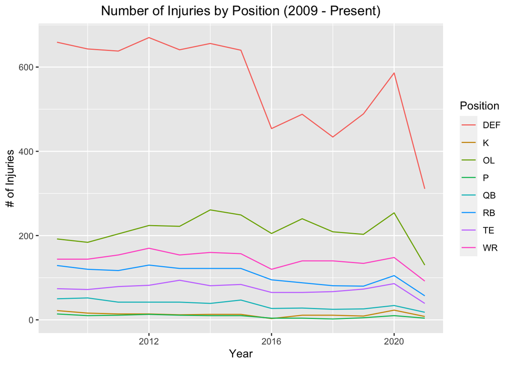

```r
number_injury %>% ggplot(aes(year, n, color = position_id)) +
                    geom_line() +
                    xlab("Year") +
                    ylab("# of Injuries") +
                    scale_color_discrete(name = "Position") +
                    ggtitle("Number of Injuries by Position (2009 - Present)")
```

### What about injuries per year? Is this uniformly distributed?

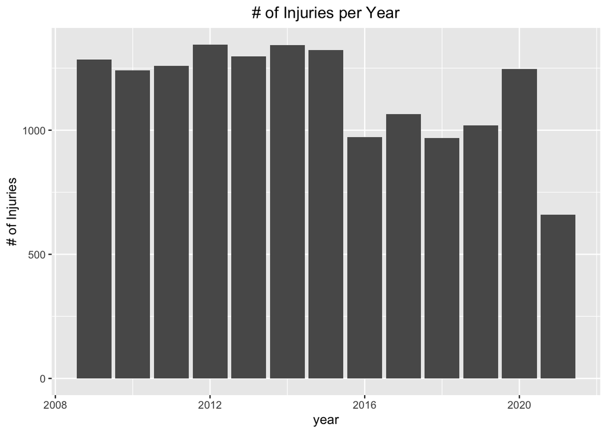

```r
injuries %>% ggplot(aes(year)) +
              geom_bar() +
              ylab("# of Injuries") +
              ggtitle("# of Injuries per Year")
```

### We now will switch to another dataset that contains information for both injured and non-injured players.

```r
players_dat = read.csv("all_players_some_injuries2021-11-16.csv")

players = players_dat %>%
            filter(year == 2018) %>%
            mutate(injury = as.factor(ifelse(is.na(injury_types), 0, 1)), # make binary injury variable
                   position_id = as.factor(position_id), # make position categorical
                   bmi = weight_pounds / height_inches^2, # make BMI variable
                   age = age(ymd(birthdate)) - 3) %>% # subtract 3 years to match age in 2018
            filter(position_id != "")
```

### Our first step is to check for missing data in our predictors and outcome

```r
apply(players %>%
        select(injury, bmi, height_inches, weight_pounds, position_id, age), 2,
      function(x) sum(is.na(x))) %>% pander
```

| injury | bmi | height_inches | weight_pounds | position_id | age |
| --- | --- | --- | --- | --- | --- |
| 0 | 0 | 0 | 0 | 0 | 0 |

**Fortunately, there are no missing observations for these features in the 2018 season.**

### What is the distribution of injuries by position in 2018?

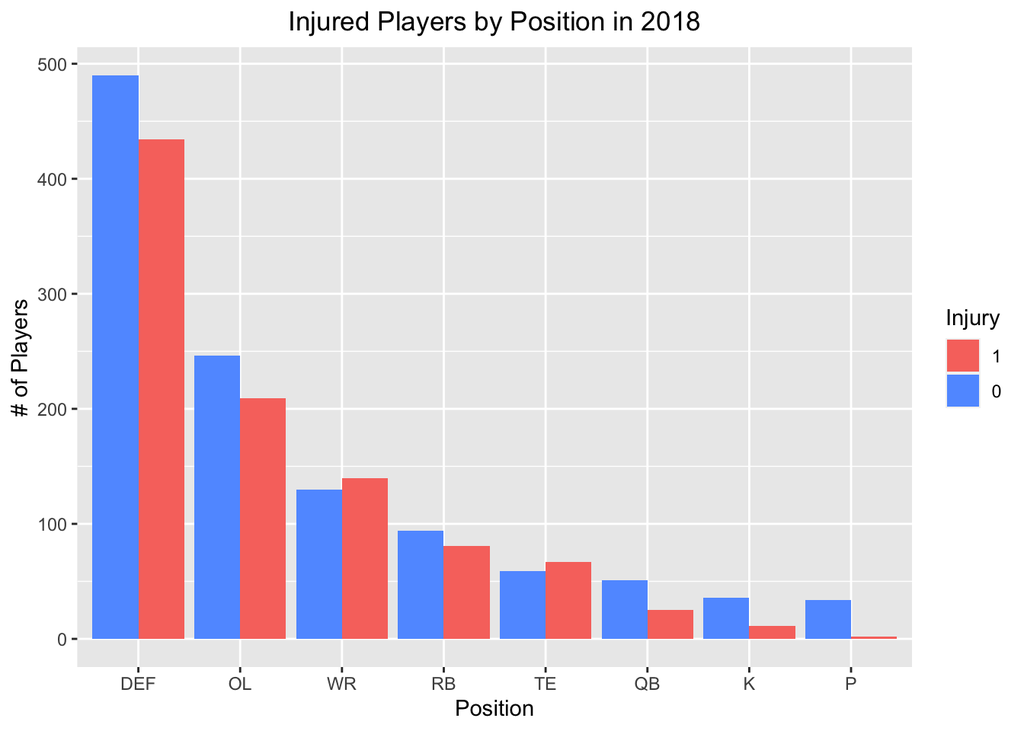

```r
players$position_id =
  fct_relevel(players$position_id, c("DEF", "OL", "WR", "RB", "TE", "QB", "K", "P", ""))

players %>%
  ggplot(aes(position_id, fill = injury)) +
    geom_bar(position = "dodge") +
    xlab("Position") +
    ylab("# of Players") +
    ggtitle("Injured Players by Position in 2018") +
    scale_fill_manual(name = "Injury", guide = guide_legend(reverse=TRUE), values = c("#619CFF", "#F8766D"))
```

**The graph above is very useful for determining whether a logistic regression coefficient would likely be statistically significant. We are looking to see, for a given position, if there is a large discrepancy between the number of injured and non-injured players. If the number of players injured is much larger than the number of non-injured players, then we would expect that the odds of getting injured in this position is large. We would expect the opposite to be the case for a position where the number of non-injured players is much greater than the number of injured players.**

### What is the distribution of BMI for the injured vs non-injured players?

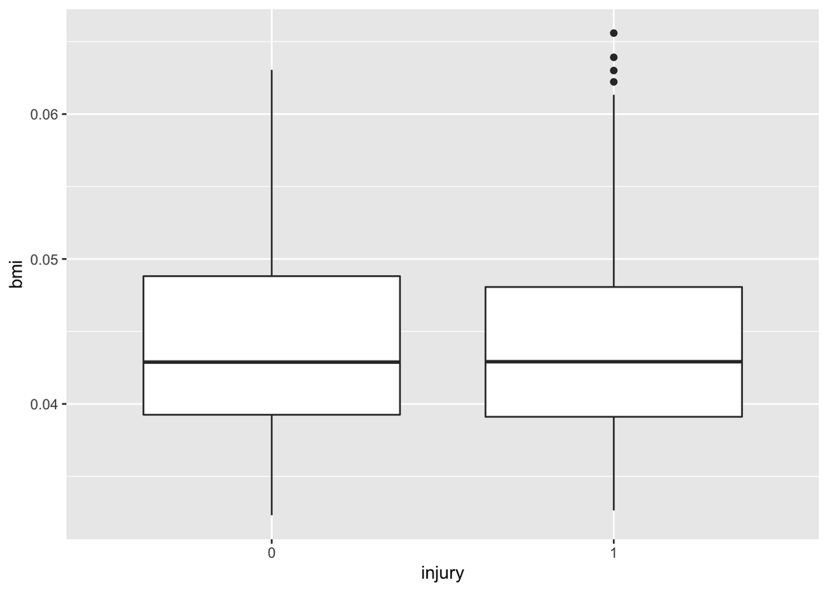

```r
players %>% ggplot(aes(injury, bmi)) +
              geom_boxplot()
```

**The absence of any significant difference between groups suggests that `bmi` will not be a significiant predictor in our Logistic model.**

### What is the distribution of `injury` by `age` in 2018?

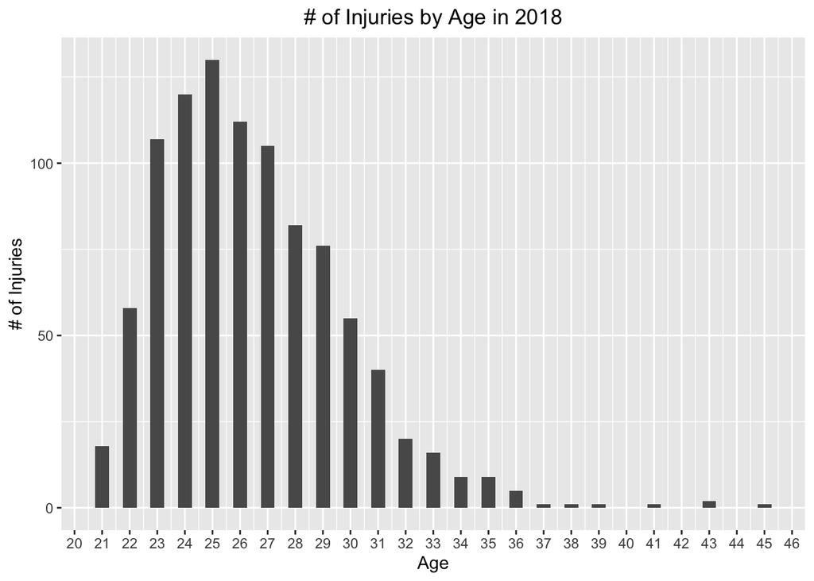

```r
injuries %>% filter(year == 2018) %>%
             mutate(age = age - 3) %>% # make age same as it was in 2018 (3 years ago)
             ggplot(aes(age)) +
               geom_histogram(binwidth = 0.5) +
               xlab("Age") +
               ylab("# of Injuries") +
               ggtitle("# of Injuries by Age in 2018") +
               scale_x_continuous(breaks = seq(0, 50, 1))
```

### Logistic regression (model only; check for significant coefficients)

```r
players = players %>% mutate(position_id = relevel(position_id, ref = "TE"))

logi_fit = glm(data = players, injury ~ position_id + bmi + age, family = binomial())
pander(summary(logi_fit))
```

|  | Estimate | Std. Error | z value | Pr(>\|z\|) |
| --- | --- | --- | --- | --- |
| **(Intercept)** | -1.462 | 0.5359 | -2.729 | 0.006354 |
| **position_idDEF** | -0.2148 | 0.1922 | -1.118 | 0.2636 |
| **position_idOL** | -0.2174 | 0.2135 | -1.018 | 0.3086 |
| **position_idWR** | -0.07473 | 0.2224 | -0.336 | 0.7369 |
| **position_idRB** | -0.2123 | 0.2362 | -0.8986 | 0.3689 |
| **position_idQB** | -1.117 | 0.3123 | -3.576 | 0.0003489 |
| **position_idK** | -1.648 | 0.4027 | -4.093 | 4.265e-05 |
| **position_idP** | -3.226 | 0.7553 | -4.271 | 1.946e-05 |
| **bmi** | -14.22 | 8.808 | -1.614 | 0.1065 |
| **age** | 0.08437 | 0.01444 | 5.844 | 5.095e-09 |

(Dispersion parameter for binomial family taken to be 1 )

| Null deviance: | 2910 on 2108 degrees of freedom |
| --- | --- |
| Residual deviance: | 2822 on 2099 degrees of freedom |

### Why is `DEF` not significant? We see there is almost an even split between injured and non-injured players

```r
players %>% filter(injury == 1) %>% select(position_id) %>% table() %>% pander(caption = "Injured")
```

Injured

| TE | DEF | OL | WR | RB | QB | K | P |  |
| --- | --- | --- | --- | --- | --- | --- | --- | --- |
| 67 | 434 | 209 | 140 | 81 | 25 | 11 | 2 | 0 |

```r
players %>% filter(injury == 0) %>% select(position_id) %>% table() %>% pander(caption = "non-Injured")
```

non-Injured

| TE | DEF | OL | WR | RB | QB | K | P |  |
| --- | --- | --- | --- | --- | --- | --- | --- | --- |
| 59 | 490 | 246 | 130 | 94 | 51 | 36 | 34 | 0 |